# Test a Perceptual Phenomenon

### Question 1: Identify variables in the experiment

Independant variable = Word condition

Dependant variable = Response time in seconds

### Question 2: Establish a hypothesis and statistical test

Null hypothesis (H₀) = There is no significant difference in the population average response times between the congruent and incongruent tasks.

Alternative hypothesis (Hₐ) = There is a significant difference, either positive or negative, in the population average response times between the congruent and incongruent tasks.

The appropriate statistical test to use is the **dependent t-test** as the possible difference between the congruent and incongruent words condition's response times in the sample can be either positive or negative. Furthermore, the test is dependent as the same sample of subjects are doing both, the congruent and incongruent tasks, and no population parameters are provided. This test will provide evidence to support or deny the null hypothesis.

### Question 3: Report descriptive statistics

```python
import pandas as pd


data_frame = pd.read_csv(r'~/Desktop/Udacity_Data_Analyst/P1/stroopdata.csv')

data_frame.describe()
```

|  | Congruent | Incongruent |
| --- | --- | --- |
| count | 24.000000 | 24.000000 |
| mean | 14.051125 | 22.015917 |
| std | 3.559358 | 4.797057 |
| min | 8.630000 | 15.687000 |
| 25% | 11.895250 | 18.716750 |
| 50% | 14.356500 | 21.017500 |
| 75% | 16.200750 | 24.051500 |
| max | 22.328000 | 35.255000 |

### Question 4: Plot the data

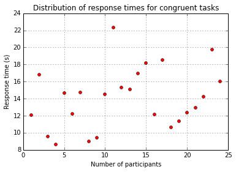

```python
import matplotlib.pyplot as plt
%pylab inline


data_frame['num_participants'] = data_frame.index + 1
x = data_frame['num_participants']
congruent_y = data_frame['Congruent']
incongruent_y = data_frame['Incongruent']

plt.plot(x, congruent_y, 'o', markersize=5, color='r')
plt.title('Distribution of response times for congruent tasks')
plt.xlabel('Number of participants')
plt.ylabel('Response time (s)')
plt.grid()
```

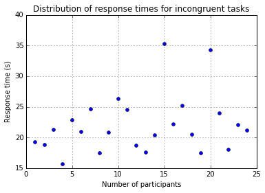

```python
plt.plot(x, incongruent_y, 'o', markersize=5, color='b')
plt.title('Distribution of response times for incongruent tasks')
plt.xlabel('Number of participants')
plt.ylabel('Response time (s)')
plt.grid()
```

The above graphs illustrates the response time distributions for the congruent and incongruent tasks, respectively. It can be easily observed that on average the incongruent tasks (22s) takes longer than congruent tasks (14s).

### Question 5: Perform the statistical test and interpret your results

[output not shown]

```python
from scipy import stats

stats.ttest_rel(data_frame['Congruent'], data_frame['Incongruent'])
```

```
(-8.020706944109957, 4.1030005857111781e-08)
```

With a t-value of -8.02 that is less than the t-critical of -2.064, and a p-value of much less than 0.0001, the null hypothesis is rejected with a 95% confidence. There is evidence to support the hypothesis that response times are significantly different between congruent and incongruent tasks with the latter taking longer than the former. This finding matches my expectations as I observed myself taking comparitively longer on the incongruent tasks.

### Question 6: Digging deeper and extending the investigation

There are several theories used to explain the stroop effect, but I believe that I comes down to habit - we tend to recognize words as shapes and patterns by default and automatically process and interalize these words before analyzing the colour. With some practice, I was able to get similar times on the stroop test.

Instead of the play on words and their colors, the mingling of numerical values and their size would have similar effect. This is known as the Numerical Stroop effect. Subjects are shown a pair of digits with varying physical and numerical dimensions, and asked to perform various tasks with these digits.

### References

- [Pandas documentation](http://pandas.pydata.org/pandas-docs/stable/10min.html)
- [Introduction to matplotlib](http://www.astro.washington.edu/users/vanderplas/Astr599/notebooks/06_MatplotlibIntro)
- [SciPy documentation](http://docs.scipy.org/doc/scipy/reference/generated/scipy.stats.ttest_rel.html)
- [Stroop effect](https://en.wikipedia.org/wiki/Stroop_effect)
- [Numerical Stroop effect](https://en.wikipedia.org/wiki/Numerical_Stroop_effect)